# Outside Item Memory

> This notebook focuses on item memory outside the rooms.

# 1 Overview of the data

The rooms were separated into *Familiar* and *Novel* groups. Participants explored the *Familiar* group at the beginning of the experiment. In the encoding task, they visisted both *Familiar* and *Novel* groups. Their item memory (i.e., in which room they saw the item) was tested in the memory test the next day of the encoding task. **Novelty benefits** on the item memory are examined by comparing the memory performance between the *Familiar* and *Novel* groups.

Participants were also asked to rate how curious they felt about the room. The higher the rating is means they felt more curious about the room. Item memory as a function of curiosity rating was also examined for **curiosity benefits**.

Questionnaires on personal traits regarding curiosity were also administered to participants before the encoding task (i.e., PC and EC). Scores on these questionnaires might be able to predict the item memory or its relationship with curiosity rating.

In the encoding task, there were 6 objects in each room. It is possbile that the item memory for the object to some extent depends on the order in which the object was seen. For example, it may be easier to remember where the first and last objects were seen as compared to those in the middle.

# 2 Visual inspection of the data

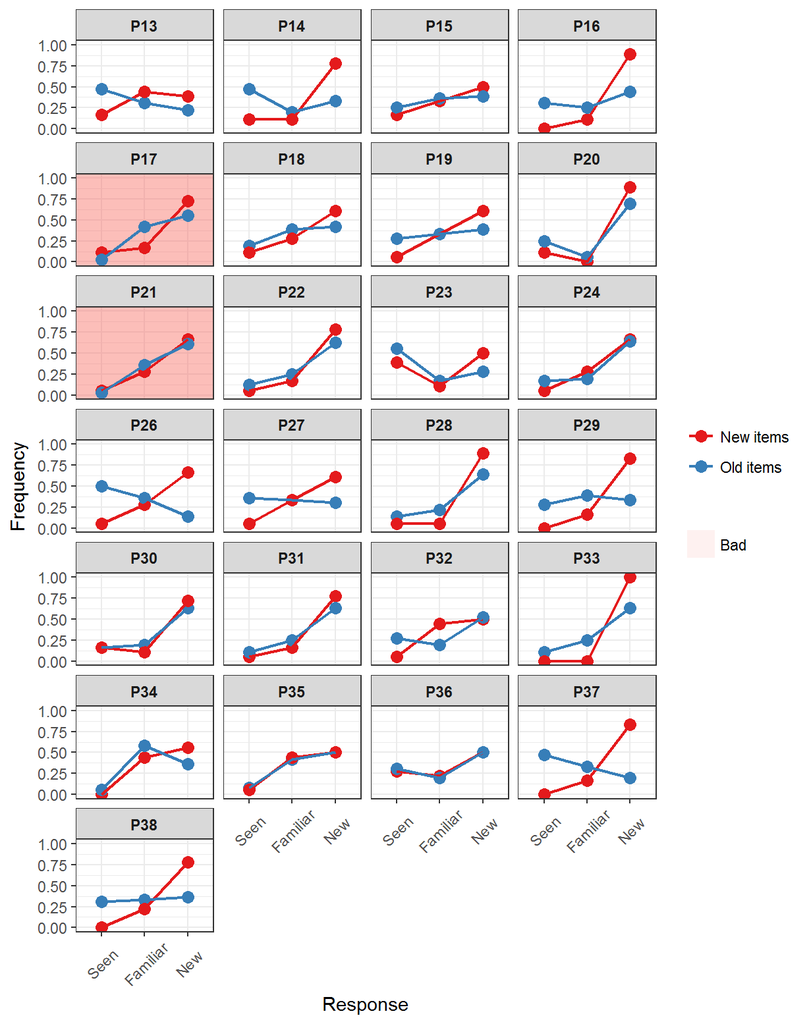

Figure 1. Response frequency for new and old items respectively for each individual participant.

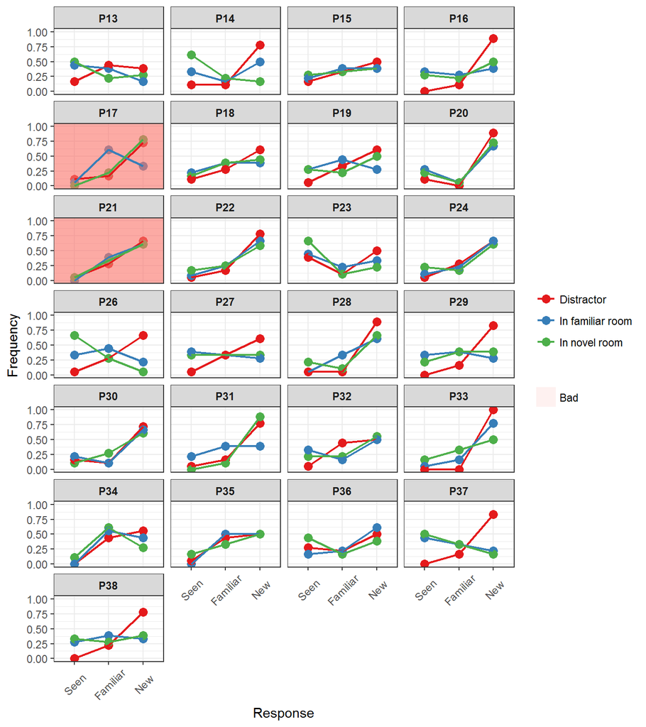

Figure 2. Response frequency for new and old items respectively for each Familiar/Novel group and each individual participant.

# 3 Novelty Benefits

We hypothesised that the memory for the items outside the rooms should be better for the *novel* rooms than for the *familiar* rooms.

## 3.1 Compare mean accuracy between *novel* and *familiar* rooms

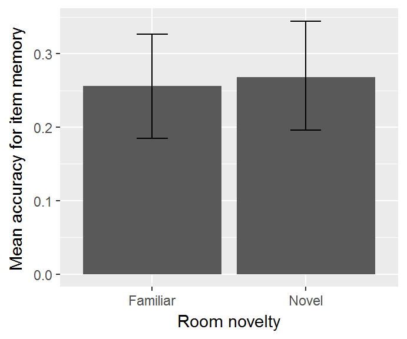

Figure 3. Mean accuracy for item memory respectively for Familiar and Novel rooms.

```
##
##  Paired t-test
##
## data:  MeanItemAccuracy by Group
## t = -0.36639, df = 22, p-value = 0.7176
## alternative hypothesis: true difference in means is not equal to 0
## 95 percent confidence interval:
##  -0.08043844  0.05628386
## sample estimates:
## mean of the differences
##             -0.01207729
```

The difference didn’t reach significance, but we only had 23 good participants.

## 3.2 Item memory as a function of item order

### 3.2.1 Visualise the data

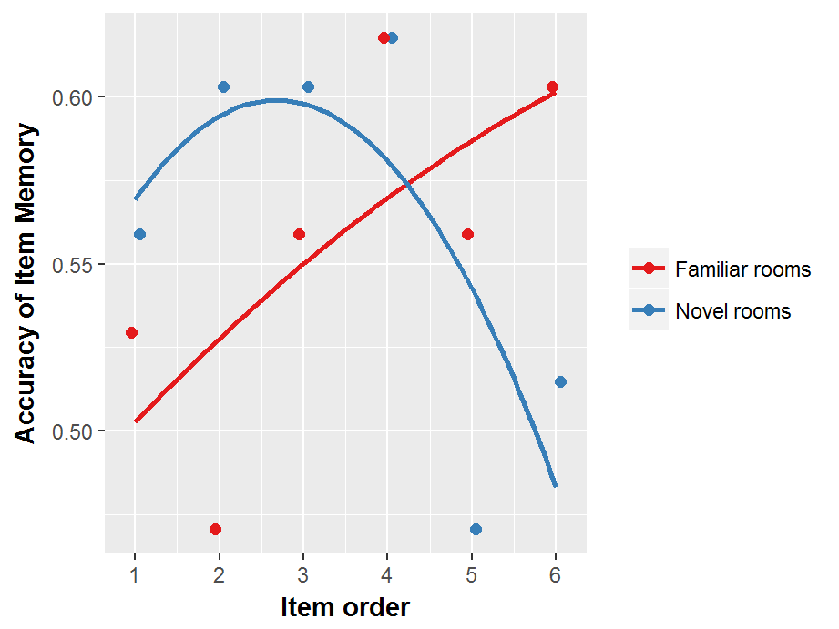

Figure 4. Mean accuracy of item memory for items at each order (i.e., 1st, 2nd, 3rd, etc), respectively for familiar and novel rooms.

For *familiar* rooms the accuracy of item memory increases with the item order, but the pattern was not obvious for the *novel* rooms. Note that we only have 23 participants here.

### 3.2.2 Testing novelty effects by fitting mixed models

Build models with item memory accuracy as $y$ and then examine effects of novelty by comparing the models.

- `baseline.item` is the model with only an intercept.
- `order.model.linear.1` is the model with $\small ItemOrder$ included, showing the effects of item order.
- `order.model.linear.2` is the model allowing the slope (i.e., relationship between item memory and item order) varying across participants.
- `order.model.quad.1` and `order.model.quad.2` repectively included $\small ItemOrder^2$ and related random effects.
- `novelty.model.1` is the model with $\small Group$ (i.e., *familiar* and *novel* rooms) included, examining the effects of novelty of the rooms on the intercept (i.e., mean item memory accuracy at the 1st order or overall if no difference in slope).
- `novelty.model.2` is the model with interaction between $\small Group$ and $\small ItemOrder$ included, examining the effects of novelty on how item memory accuracy changes as a function of item order.
- `novelty.model.3` included interaction between $\small Group$ and $\small ItemOrder^2$ for inestigating whether the pattern changes between *familiar* and *novel* groups.

```
##                      Model df      AIC      BIC    logLik   Test  L.Ratio
## baseline.item            1  3 1144.405 1158.518 -569.2023
## order.model.linear.1     2  4 1146.388 1165.206 -569.1940 1 vs 2 0.016645
## order.model.linear.2     3  6 1150.276 1178.503 -569.1381 2 vs 3 0.111836
## order.model.quad.1       4  7 1151.493 1184.424 -568.7466 3 vs 4 0.782974
## order.model.quad.2       5 10 1154.188 1201.232 -567.0939 4 vs 5 3.305456
## novelty.model.1          6 11 1156.166 1207.914 -567.0828 5 vs 6 0.022121
## novelty.model.2          7 12 1154.486 1210.939 -565.2429 6 vs 7 3.679758
## novelty.model.3          8 13 1155.999 1217.157 -564.9997 7 vs 8 0.486414
##                      p-value
## baseline.item
## order.model.linear.1  0.8973
## order.model.linear.2  0.9456
## order.model.quad.1    0.3762
## order.model.quad.2    0.3469
## novelty.model.1       0.8818
## novelty.model.2       0.0551
## novelty.model.3       0.4855
```

Including none of the predictors significantly improved the model fit.

#### 3.2.2.1 Parameter estimation for the complete model

```
## Linear mixed-effects model fit by maximum likelihood
##  Data: Curiosity.Recall.Old[!SubjectNo %in% bad.ps.less.strict]
##        AIC      BIC    logLik
##   1155.999 1217.157 -564.9997
##
## Random effects:
##  Formula: ~1 + ItemOrder + I(ItemOrder^2) | SubjectNo
##  Structure: General positive-definite, Log-Cholesky parametrization
##                StdDev     Corr
## (Intercept)    0.25645941 (Intr) ItmOrd
## ItemOrder      0.17147883 -0.815
## I(ItemOrder^2) 0.02540466  0.781 -0.991
## Residual       0.46904318
##
## Fixed effects: Accuracy ~ ItemOrder + I(ItemOrder^2) + Group + ItemOrder:Group +      I(ItemOrder^2):Group
##                                Value  Std.Error  DF   t-value p-value
## (Intercept)                0.4720158 0.11540909 788  4.089937  0.0000
## ItemOrder                  0.0298163 0.07587001 788  0.392992  0.6944
## I(ItemOrder^2)            -0.0014377 0.01075465 788 -0.133682  0.8937
## GroupNovel                 0.0485294 0.14442784 788  0.336011  0.7370
## ItemOrder:GroupNovel       0.0273634 0.09448864 788  0.289595  0.7722
## I(ItemOrder^2):GroupNovel -0.0091912 0.01321379 788 -0.695574  0.4869
##  Correlation:
##                           (Intr) ItmOrd I(ItO^2) GrpNvl ItO:GN
## ItemOrder                 -0.906
## I(ItemOrder^2)             0.837 -0.981
## GroupNovel                -0.626  0.580 -0.525
## ItemOrder:GroupNovel       0.583 -0.623  0.601   -0.931
## I(ItemOrder^2):GroupNovel -0.534  0.610 -0.614    0.854 -0.979
##
## Standardized Within-Group Residuals:
##        Min         Q1        Med         Q3        Max
## -1.7382959 -0.9656917  0.4997078  0.8336464  1.6176708
##
## Number of Observations: 816
## Number of Groups: 23
```

# 4 Curiosity Benefits

We hypothesed that the higher the curiosity rating was, the better the item memory should be.

## 4.1 Mean accuracy of item memory as a function of curiosity rating

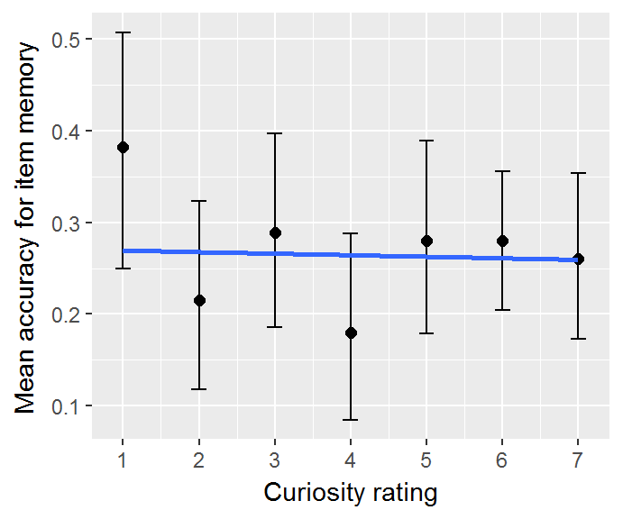

Figure 5. Mean accuracy for item memory as a function of curiosity rating.

### 4.1.1 Testing the relationship between mean accuracy of item memory and curiosity rating

Build models with item memory accuracy as $y$ and examine effects of curiosity rating by including it into the model and then comparing the model fits.

- `baseline.rating` is the model with only an intercept, showing no change in item memory as a function of curiosity rating.
- `rating.intercept` is the model with $\small CuriosityRating$ included, showing the effects of curiosity rating.
- `rating.slope` is the model allowing the slope (i.e., relationship between item memory and curiosity rating) varying across participants.

```
##                  Model df       AIC       BIC   logLik   Test   L.Ratio
## baseline.rating      1  3 -39.08440 -30.34644 22.54220
## rating.intercept     2  4 -37.13462 -25.48400 22.56731 1 vs 2 0.0502197
## rating.slope         3  6 -34.70707 -17.23114 23.35353 2 vs 3 1.5724430
##                  p-value
## baseline.rating
## rating.intercept  0.8227
## rating.slope      0.4556
```

#### 4.1.1.1 Parameter estimates in the complete model

```r
summary(rating.slope)
```

```
## Linear mixed-effects model fit by maximum likelihood
##  Data: OutsideObjectsMemory[!SubjectNo %in% bad.ps.less.strict]
##         AIC       BIC   logLik
##   -34.70707 -17.23114 23.35353
##
## Random effects:
##  Formula: ~1 + CuriosityRating | SubjectNo
##  Structure: General positive-definite, Log-Cholesky parametrization
##                 StdDev     Corr
## (Intercept)     0.17794697 (Intr)
## CuriosityRating 0.02694161 -0.572
## Residual        0.17134592
##
## Fixed effects: ItemAccuracy ~ CuriosityRating
##                      Value  Std.Error  DF  t-value p-value
## (Intercept)     0.24823272 0.05610060 112 4.424778  0.0000
## CuriosityRating 0.00284607 0.01020185 112 0.278976  0.7808
##  Correlation:
##                 (Intr)
## CuriosityRating -0.79
##
## Standardized Within-Group Residuals:
##        Min         Q1        Med         Q3        Max
## -1.7802570 -0.6671109 -0.1547727  0.4335029  3.1879966
##
## Number of Observations: 136
## Number of Groups: 23
```

#### 4.1.1.2 Plot the model

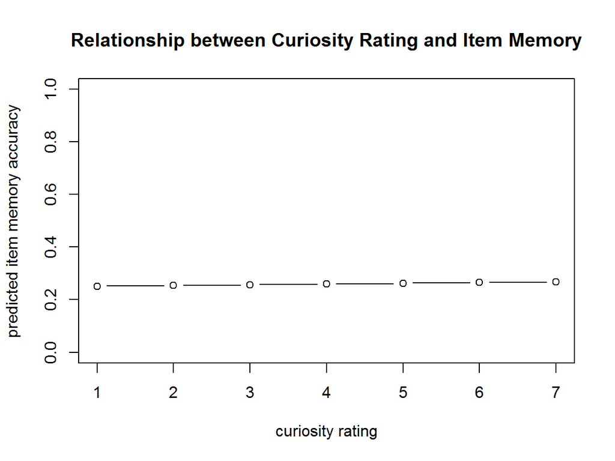

## 4.2 Does the relationship with curiosity rating depend on item order?

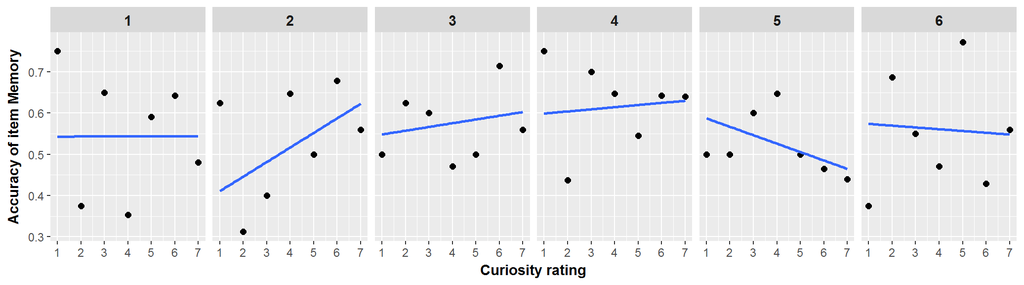

Figure 6. Mean accuracy across participants for item memory as a function of curiosity rating for each order at which the item was seen (I.e., 1st, 2nd, 3rd, etc.).

### 4.2.1 Testing the effect of item order

Build models with context memory accuracy as $y$ and examine effects of curiosity rating and item order by comparing the models.

- `item.model.linear.1` is the model with $\small ItemOrder$ included (in addition to $\small CuriosityRating$), showing the effects of item order.
- `item.model.linear.2` is the model allowing the slope (i.e., relationship between item memory and item order) varying across participants.
- `item.model.linear.3` is the model with the interaction between $\small ItemOrders$ and $\small CuriosityRating$ included.
- `item.model.quad.1` and `item.model.quad.2` repectively included $\small ItemOrder^2$ and related random effects.
- `item.model.quad.3` included interaction between $\small ItemOrder^2$ and $\small CuriosityRating$ for inestigating whether the pattern changes as a function of *curiosity rating*.

```r
rating.intercept <- update(baseline.item, .~. + CuriosityRating)
rating.slope     <- update(rating.intercept, random = ~ 1 + CuriosityRating | SubjectNo)

item.model.linear.1     <- update(rating.slope, .~. + ItemOrder)
item.model.linear.2     <- update(item.model.linear.1, random = list(~1+CuriosityRating|SubjectNo, ~1+ItemOrder|SubjectNo))
item.model.linear.3     <- update(item.model.linear.2, .~. + ItemOrder : CuriosityRating)

item.model.quad.1       <- update(item.model.linear.3, .~. + I(ItemOrder^2))
# item.model.quad.2       <- update(item.model.quad.1,   random = list(~1+CuriosityRating|SubjectNo, ~1+ItemOrder+I(ItemOrder^2)|SubjectNo)) - excluding this model because singularity issue (perhaps the model was getting too complex to be calculated)
item.model.quad.3       <- update(item.model.quad.1,   .~. + I(ItemOrder^2) : CuriosityRating)

anova(rating.intercept, rating.slope, item.model.linear.1, item.model.linear.2, item.model.linear.3, item.model.quad.1, item.model.quad.3)
```

```
##                     Model df      AIC      BIC    logLik   Test   L.Ratio
## rating.intercept        1  4 1146.367 1165.185 -569.1836
## rating.slope            2  6 1147.637 1175.863 -567.8185 1 vs 2 2.7302745
## item.model.linear.1     3  7 1149.620 1182.551 -567.8100 2 vs 3 0.0169281
## item.model.linear.2     4 10 1155.465 1202.509 -567.7325 3 vs 4 0.1549485
## item.model.linear.3     5 11 1156.267 1208.015 -567.1333 4 vs 5 1.1985088
## item.model.quad.1       6 12 1157.468 1213.921 -566.7340 5 vs 6 0.7985641
## item.model.quad.3       7 13 1159.252 1220.410 -566.6262 6 vs 7 0.2156473
##                     p-value
## rating.intercept
## rating.slope         0.2553
## item.model.linear.1  0.8965
## item.model.linear.2  0.9845
## item.model.linear.3  0.2736
## item.model.quad.1    0.3715
## item.model.quad.3    0.6424
```

Again, adding none of the predictors significantly improved the model fit.

#### 4.2.1.1 Parameter estimation for the complete model

```r
summary(item.model.quad.3)
```

```
## Linear mixed-effects model fit by maximum likelihood
##  Data: Curiosity.Recall.Old[!SubjectNo %in% bad.ps.less.strict]
##        AIC     BIC    logLik
##   1159.252 1220.41 -566.6262
##
## Random effects:
##  Formula: ~1 + CuriosityRating | SubjectNo
##  Structure: General positive-definite, Log-Cholesky parametrization
##                 StdDev    Corr
## (Intercept)     0.1934630 (Intr)
## CuriosityRating 0.0349072 -0.858
##
##  Formula: ~1 + ItemOrder | SubjectNo %in% SubjectNo
##  Structure: General positive-definite, Log-Cholesky parametrization
##             StdDev    Corr
## (Intercept) 0.1110204 (Intr)
## ItemOrder   0.0176656 -0.479
## Residual    0.4709347
##
## Fixed effects: Accuracy ~ CuriosityRating + ItemOrder + I(ItemOrder^2) + CuriosityRating:ItemOrder +      CuriosityRating:I(ItemOrder^2)
##                                     Value  Std.Error  DF    t-value
## (Intercept)                     0.4564994 0.19859977 788  2.2985898
## CuriosityRating                 0.0083755 0.03982449 788  0.2103109
## ItemOrder                       0.0161238 0.12572009 788  0.1282517
## I(ItemOrder^2)                  0.0016194 0.01756975 788  0.0921698
## CuriosityRating:ItemOrder       0.0058053 0.02548510 788  0.2277936
## CuriosityRating:I(ItemOrder^2) -0.0016486 0.00356302 788 -0.4627109
##                                p-value
## (Intercept)                     0.0218
## CuriosityRating                 0.8335
## ItemOrder                       0.8980
## I(ItemOrder^2)                  0.9266
## CuriosityRating:ItemOrder       0.8199
## CuriosityRating:I(ItemOrder^2)  0.6437
##  Correlation:
##                                (Intr) CrstyR ItmOrd I(IO^2 CrR:IO
## CuriosityRating                -0.917
## ItemOrder                      -0.903  0.844
## I(ItemOrder^2)                  0.826 -0.773 -0.978
## CuriosityRating:ItemOrder       0.835 -0.912 -0.926  0.906
## CuriosityRating:I(ItemOrder^2) -0.765  0.835  0.906 -0.926 -0.979
##
## Standardized Within-Group Residuals:
##        Min         Q1        Med         Q3        Max
## -1.7665292 -1.0007151  0.5295572  0.8464453  1.5153538
##
## Number of Observations: 816
## Number of Groups:
##                  SubjectNo SubjectNo.1 %in% SubjectNo
##                         23                         23
```

# 5 Curiosity and novelty

## 5.1 Testing the effects of curiosity rating and novelty together

Build models with item memory accuracy as $y$ and examine effects of curiosity rating and novelty together by including them into the model separately and then comparing the model fits.

- `baseline.rating` is the model with only an intercept, showing no change in item memory as a function of curiosity rating.
- `rating.intercept` is the model with $\small CuriosityRating$ included, showing the effects of curiosity rating.
- `rating.slope` is the model allowing the slope (i.e., relationship between item memory and curiosity rating) varying across participants.
- `novelty.model` is the model with $\small Group$ (i.e., *familiar* and *novel* rooms) included, examining the effects of novelty of the rooms on the intercept (i.e., mean item memory accuracy at the 1st order or overall if no difference in slope).
- `interaction.model` is the model with interaction between $\small Group$ and $\small CuriosityRating$ included, examining the effects of novelty on how item memory accuracy changes as a function of item order.

```
##                   Model df       AIC        BIC   logLik   Test   L.Ratio
## baseline.rating       1  3 -39.08440 -30.346440 22.54220
## rating.intercept      2  4 -37.13462 -25.484005 22.56731 1 vs 2 0.0502197
## rating.slope          3  6 -34.70707 -17.231138 23.35353 2 vs 3 1.5724430
## novelty.model.1       4  7 -32.83384 -12.445251 23.41692 3 vs 4 0.1267685
## novelty.model.2       5 10 -26.83346   2.293093 23.41673 4 vs 5 0.0003795
## interaction.model     6 11 -24.89748   7.141721 23.44874 5 vs 6 0.0640271
##                   p-value
## baseline.rating
## rating.intercept   0.8227
## rating.slope       0.4556
## novelty.model.1    0.7218
## novelty.model.2    1.0000
## interaction.model  0.8002
```

### 5.1.1 Check the complete model

```
## Linear mixed-effects model fit by maximum likelihood
##  Data: OutsideObjectsMemory[!SubjectNo %in% bad.ps.less.strict]
##         AIC      BIC   logLik
##   -26.83346 2.293093 23.41673
##
## Random effects:
##  Formula: ~1 + CuriosityRating | SubjectNo
##  Structure: General positive-definite, Log-Cholesky parametrization
##                 StdDev    Corr
## (Intercept)     0.1385266 (Intr)
## CuriosityRating 0.0272727 -0.75
##
##  Formula: ~1 + Group | SubjectNo %in% SubjectNo
##  Structure: General positive-definite, Log-Cholesky parametrization
##             StdDev      Corr
## (Intercept) 0.113165785 (Intr)
## GroupNovel  0.003040829 0.015
## Residual    0.171164750
##
## Fixed effects: ItemAccuracy ~ CuriosityRating + Group
##                       Value  Std.Error  DF   t-value p-value
## (Intercept)      0.25582237 0.06053468 111  4.226046  0.0000
## CuriosityRating -0.00064542 0.01430165 111 -0.045129  0.9641
## GroupNovel       0.01653420 0.04674704 111  0.353695  0.7242
##  Correlation:
##                 (Intr) CrstyR
## CuriosityRating -0.782
## GroupNovel       0.362 -0.695
##
## Standardized Within-Group Residuals:
##        Min         Q1        Med         Q3        Max
## -1.7924987 -0.6464147 -0.1602987  0.4372073  3.2103467
##
## Number of Observations: 136
## Number of Groups:
##                  SubjectNo SubjectNo.1 %in% SubjectNo
##                         23                         23
```

## 5.2 What about the other way around

```
##                 Model df       AIC        BIC   logLik   Test   L.Ratio
## baseline.rating     1  3 -39.08440 -30.346440 22.54220
## novelty.model.1     2  4 -37.20365 -25.553031 22.60183 1 vs 2 0.1192464
## novelty.model.2     3  6 -33.80682 -16.330894 22.90341 2 vs 3 0.6031727
## rating.model.1      4  7 -31.82350 -11.434915 22.91175 3 vs 4 0.0166759
## rating.model.2      5 10 -26.83346   2.293093 23.41673 4 vs 5 1.0099566
##                 p-value
## baseline.rating
## novelty.model.1  0.7299
## novelty.model.2  0.7396
## rating.model.1   0.8973
## rating.model.2   0.7988
```

### 5.2.1 Check the model

```
## Linear mixed-effects model fit by maximum likelihood
##  Data: OutsideObjectsMemory[!SubjectNo %in% bad.ps.less.strict]
##         AIC      BIC   logLik
##   -26.83346 2.293093 23.41673
##
## Random effects:
##  Formula: ~1 + CuriosityRating | SubjectNo
##  Structure: General positive-definite, Log-Cholesky parametrization
##                 StdDev    Corr
## (Intercept)     0.1385266 (Intr)
## CuriosityRating 0.0272727 -0.75
##
##  Formula: ~1 + Group | SubjectNo %in% SubjectNo
##  Structure: General positive-definite, Log-Cholesky parametrization
##             StdDev      Corr
## (Intercept) 0.113165785 (Intr)
## GroupNovel  0.003040828 0.015
## Residual    0.171164750
##
## Fixed effects: ItemAccuracy ~ Group + CuriosityRating
##                       Value  Std.Error  DF   t-value p-value
## (Intercept)      0.25582237 0.06053468 111  4.226046  0.0000
## GroupNovel       0.01653420 0.04674704 111  0.353695  0.7242
## CuriosityRating -0.00064542 0.01430165 111 -0.045129  0.9641
##  Correlation:
##                 (Intr) GrpNvl
## GroupNovel       0.362
## CuriosityRating -0.782 -0.695
##
## Standardized Within-Group Residuals:
##        Min         Q1        Med         Q3        Max
## -1.7924987 -0.6464147 -0.1602987  0.4372073  3.2103467
##
## Number of Observations: 136
## Number of Groups:
##                  SubjectNo SubjectNo.1 %in% SubjectNo
##                         23                         23
```